#Question 1 Roller coasters are thrilling amusement park rides designed to make you squeal and scream! They take you up high, drop you to the ground quickly, and sometimes even spin you upside down before returning to a stop. Today you will be taking control back from the roller coasters and visualizing data covering international roller coaster rankings and roller coaster statistics. Roller coasters are often split into two main categories based on their construction material: wood or steel. Rankings for the best wood and steel roller coasters from the 2013 to 2018 Golden Ticket Awards are provided in 'Golden_Ticket_Award_Winners_Wood.csv' and 'Golden_Ticket_Award_Winners_Steel.csv', respectively. Load each csv into a DataFrame and inspect it to gain familiarity with the data. Open the hint for more information about each column of the datasets. #Question 2 Write a function that will plot the ranking of a given roller coaster over time as a line. Your function should take a roller coaster’s name and a ranking DataFrame as arguments. Make sure to include informative labels that describe your visualization. Call your function with "El Toro" as the roller coaster name and the wood ranking DataFrame. What issue do you notice? Update your function with an additional argument to alleviate the problem, and retest your function.

```python
#Quetion 1
import pandas as pd
import matplotlib.pyplot as plt
import matplotlib as matplotlib

Wood_Rank=pd.read_csv(r'C:\Users\Apple\Desktop\新建文件夹 (10)\roller_coaster_starting\Golden_Ticket_Award_Winners_Wood.csv')
Steel_Rank=pd.read_csv(r'C:\Users\Apple\Desktop\新建文件夹 (10)\roller_coaster_starting\Golden_Ticket_Award_Winners_Steel.csv')
pd.set_option('display.width',1000)
print(Wood_Rank.head())
print(Steel_Rank.head())
```

```
   Rank          Name                       Park             Location          Supplier  Year Built  Points  Year of Rank
0     1  Boulder Dash             Lake Compounce       Bristol, Conn.               CCI        2000    1333          2013
1     2       El Toro  Six Flags Great Adventure        Jackson, N.J.           Intamin        2006    1302          2013
2     3       Phoenix  Knoebels Amusement Resort        Elysburg, Pa.  Dinn/PTC-Schmeck        1985    1088          2013
3     4    The Voyage              Holiday World    Santa Claus, Ind.     Gravity Group        2006    1086          2013
4     5   Thunderhead                  Dollywood  Pigeon Forge, Tenn.              GCII        2004     923          2013
   Rank                Name                        Park           Location Supplier  Year Built  Points  Year of Rank
0     1    Millennium Force                 Cedar Point     Sandusky, Ohio  Intamin        2000    1204          2013
1     2             Bizarro       Six Flags New England      Agawam, Mass.  Intamin        2000    1011          2013
2     3  Expedition GeForce                Holiday Park  Hassloch, Germany  Intamin        2001     598          2013
3     4               Nitro   Six Flags Great Adventure      Jackson, N.J.      B&M        2001     596          2013
4     5    Apollo’s Chariot  Busch Gardens Williamsburg  Williamsburg, Va.      B&M        1999     542          2013
```

# Question 3

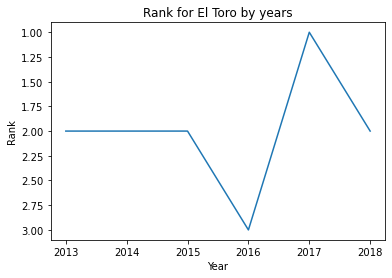

```python
#Question 3
ax=plt.subplot()
def rank_by_time (name,ranking_df):
    df_for_name=ranking_df[(ranking_df['Name']==name) & (ranking_df['Park']=='Six Flags Great Adventure')].sort_values(by='Year of Rank')
    plt.plot(range(len(df_for_name)),df_for_name['Rank'])
    ax.set_xticks(range(len(df_for_name)))
    ax.set_xticklabels(df_for_name['Year of Rank'])
    plt.title('Rank for '+name+' by years')
    plt.xlabel('Year')
    plt.ylabel('Rank')
    plt.gca().invert_yaxis()
    plt.show()
    plt.clf()
rank_by_time ('El Toro',Wood_Rank)
```

# Question 4

Write a function that will plot the ranking of two given roller coasters over time as lines. Your function should take both roller coasters’ names and a ranking DataFrame as arguments. Make sure to include informative labels that describe your visualization.

Call your function with "El Toro" as one roller coaster name, “Boulder Dash“ as the other roller coaster name, and the wood ranking DataFrame. What issue do you notice? Update your function with two additional arguments to alleviate the problem, and retest your function.

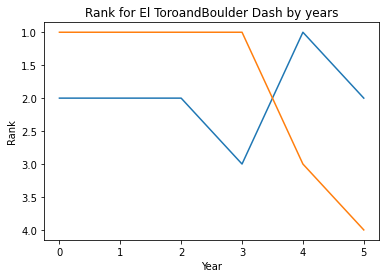

```python
#Question 4
def two_rank_by_time (name1,name2,ranking_df):
  df_for_name1=ranking_df[(ranking_df['Name']==name1) & (ranking_df['Park']=='Six Flags Great Adventure')].sort_values(by='Year of Rank')
  df_for_name2=ranking_df[ranking_df['Name']==name2].sort_values(by='Year of Rank')


  plt.plot(range(len(df_for_name1)),df_for_name1['Rank'])
  plt.plot(range(len(df_for_name2)),df_for_name2['Rank'])

  if len(df_for_name1)>=len(df_for_name2):
    ax.set_xticks(range(len(df_for_name1)))
    ax.set_xticklabels(df_for_name1['Year of Rank'])
  else:
    ax.set_xticks(range(len(df_for_name2)))
    ax.set_xticklabels(df_for_name2['Year of Rank'])
  plt.title('Rank for '+name1+'and'+name2+' by years')
  plt.xlabel('Year')
  plt.ylabel('Rank')
  plt.gca().invert_yaxis()
  plt.show()
  plt.clf()

two_rank_by_time ('El Toro','Boulder Dash',Wood_Rank)
```

# Question 5

Write a function that will plot the ranking of the top n ranked roller coasters over time as lines. Your function should take a number n and a ranking DataFrame as arguments. Make sure to include informative labels that describe your visualization.

For example, if n == 5, your function should plot a line for each roller coaster that has a rank of 5 or lower.

Call your function with a value for n and either the wood ranking or steel ranking DataFrame.

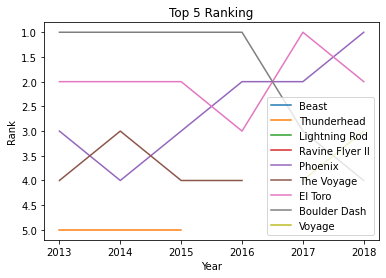

```python
#Question 5
def top_rank_by_time (n,rankings_df):
  top_n_rankings = rankings_df[rankings_df['Rank'] <= n]
  for coaster in set(top_n_rankings['Name']):
    coaster_rankings = top_n_rankings[top_n_rankings['Name'] == coaster]
    plt.plot(coaster_rankings['Year of Rank'],coaster_rankings['Rank'],label=coaster)
  plt.legend(loc=4)
  plt.xlabel('Year')
  plt.ylabel('Rank')
  plt.title('Top '+str(n)+' Ranking')
  plt.gca().invert_yaxis() #逆转y轴的顺序
  plt.show()
  plt.clf()
top_rank_by_time (5,Wood_Rank)
```

# Question 6

Now that you’ve visualized rankings over time, let’s dive into the actual statistics of roller coasters themselves. Captain Coaster is a popular site for recording roller coaster information. Data on all roller coasters documented on Captain Coaster has been accessed through its API and stored in roller_coasters.csv. Load the data from the csv into a DataFrame and inspect it to gain familiarity with the data.

Open the hint for more information about each column of the dataset.

# Question 7

Write a function that plots a histogram of any numeric column of the roller coaster DataFrame. Your function should take a DataFrame and a column name for which a histogram should be constructed as arguments. Make sure to include informative labels that describe your visualization.

Call your function with the roller coaster DataFrame and one of the column names.

```
            name material_type seating_type  speed  height  length  num_inversions     manufacturer            park            status
0       Goudurix         Steel     Sit Down   75.0    37.0   950.0             7.0           Vekoma    Parc Asterix  status.operating
1  Dream catcher         Steel    Suspended   45.0    25.0   600.0             0.0           Vekoma   Bobbejaanland  status.operating
2     Alucinakis         Steel     Sit Down   30.0     8.0   250.0             0.0         Zamperla    Terra Mítica  status.operating
3       Anaconda        Wooden     Sit Down   85.0    35.0  1200.0             0.0  William J. Cobb  Walygator Parc  status.operating
4         Azteka         Steel     Sit Down   55.0    17.0   500.0             0.0           Soquet          Le Pal  status.operating
```

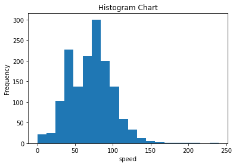

```python
#Question 6
Coaster=pd.read_csv(r'C:\Users\Apple\Desktop\新建文件夹 (10)\roller_coaster_starting\roller_coasters.csv')
print(Coaster.head())

#Question 7
def question_7(df,column_name):
  target=df[column_name].dropna() #在画图之前记得先去除nan的值
  plt.hist(target,bins=20)
  plt.title('Histogram Chart')
  plt.xlabel(column_name)
  plt.ylabel('Frequency')
  plt.show()
  plt.clf()
question_7(Coaster,'speed')
```

# Question 8

Write a function that creates a bar chart showing the number of inversions for each roller coaster at an amusement park. Your function should take the roller coaster DataFrame and an amusement park name as arguments. Make sure to include informative labels that describe your visualization.

Call your function with the roller coaster DataFrame and an amusement park name.

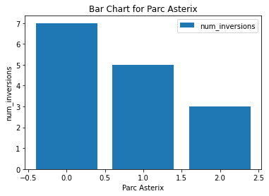

```python
#Question 8
def question_8(Coaster,park_name):
  row=Coaster[(Coaster['park']==park_name) & (Coaster['num_inversions']!=0)]
  plt.bar(range(len(row['name'])),row['num_inversions'],label='num_inversions')
  ax.set_xticks(range(len(row['name'])))
  ax.set_xticklabels(row['name'],fontsize=8,rotation = -30)
  plt.title('Bar Chart for '+park_name)
  plt.xlabel(park_name)
  plt.ylabel('num_inversions')
  plt.legend()
  plt.show()
  plt.clf()

question_8(Coaster,'Parc Asterix')
```

# Question 9

Write a function that creates a pie chart that compares the number of operating roller coasters ('status.operating') to the number of closed roller coasters ('status.closed.definitely'). Your function should take the roller coaster DataFrame as an argument. Make sure to include informative labels that describe your visualization.

Call your function with the roller coaster DataFrame.

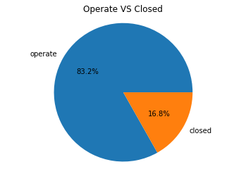

```python
#Question 9
def question_9_pie(Coaster):
  operating=len(Coaster[Coaster['status']=='status.operating'])
  closed=len(Coaster[Coaster['status']=='status.closed.definitely'])
  plt.pie([operating,closed],labels=['operate','closed'],autopct='%0.01f%%')
  plt.title('Operate VS Closed')
  plt.axis('equal')
  plt.show()
  plt.clf()
question_9_pie(Coaster)
```

# Question 10

.scatter() is another useful function in matplotlib that you might not have seen before. .scatter() produces a scatter plot, which is similar to .plot() in that it plots points on a figure. .scatter(), however, does not connect the points with a line. This allows you to analyze the relationship between to variables. Find .scatter()‘s documentation here.

Write a function that creates a scatter plot of two numeric columns of the roller coaster DataFrame. Your function should take the roller coaster DataFrame and two-column names as arguments. Make sure to include informative labels that describe your visualization.

Call your function with the roller coaster DataFrame and two-column names.

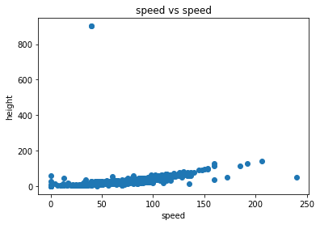

```python
#Question 10
def question_10_scatter(Coaster,name1,name2):
  plt.scatter(Coaster[name1],Coaster[name2])
  plt.xlabel(name1)
  plt.ylabel(name2)
  plt.title('{} vs {}'.format(name1,name1))
  plt.show()
  plt.clf()
question_10_scatter(Coaster,'speed','height')
```